# Risk Factor Analysis

## Outcome Variable

**Outcome Variable:** wast_rec90d

## Predictor Variables

**Intervention Variable:** perdiar6

**Adjustment Set:**

unadjusted

## Stratifying Variables

The analysis was stratified on these variable(s):

- agecat
- studyid
- country

## Data Summary

| agecat | studyid | country | perdiar6 | wast_rec90d | n_cell | n |
| --- | --- | --- | --- | --- | --- | --- |
| 0-24 months | CMIN | BANGLADESH | 0% | 0 | 28 | 190 |
| 0-24 months | CMIN | BANGLADESH | 0% | 1 | 43 | 190 |
| 0-24 months | CMIN | BANGLADESH | (0%, 5%] | 0 | 19 | 190 |
| 0-24 months | CMIN | BANGLADESH | (0%, 5%] | 1 | 16 | 190 |
| 0-24 months | CMIN | BANGLADESH | >5% | 0 | 33 | 190 |
| 0-24 months | CMIN | BANGLADESH | >5% | 1 | 51 | 190 |
| 0-24 months | CONTENT | PERU | 0% | 0 | 0 | 7 |
| 0-24 months | CONTENT | PERU | 0% | 1 | 1 | 7 |
| 0-24 months | CONTENT | PERU | (0%, 5%] | 0 | 0 | 7 |
| 0-24 months | CONTENT | PERU | (0%, 5%] | 1 | 1 | 7 |
| 0-24 months | CONTENT | PERU | >5% | 0 | 1 | 7 |
| 0-24 months | CONTENT | PERU | >5% | 1 | 4 | 7 |
| 0-24 months | EE | PAKISTAN | 0% | 0 | 149 | 323 |
| 0-24 months | EE | PAKISTAN | 0% | 1 | 141 | 323 |
| 0-24 months | EE | PAKISTAN | (0%, 5%] | 0 | 11 | 323 |
| 0-24 months | EE | PAKISTAN | (0%, 5%] | 1 | 18 | 323 |
| 0-24 months | EE | PAKISTAN | >5% | 0 | 0 | 323 |
| 0-24 months | EE | PAKISTAN | >5% | 1 | 4 | 323 |
| 0-24 months | MAL-ED | BANGLADESH | 0% | 0 | 16 | 124 |
| 0-24 months | MAL-ED | BANGLADESH | 0% | 1 | 22 | 124 |
| 0-24 months | MAL-ED | BANGLADESH | (0%, 5%] | 0 | 20 | 124 |
| 0-24 months | MAL-ED | BANGLADESH | (0%, 5%] | 1 | 34 | 124 |
| 0-24 months | MAL-ED | BANGLADESH | >5% | 0 | 8 | 124 |
| 0-24 months | MAL-ED | BANGLADESH | >5% | 1 | 24 | 124 |
| 0-24 months | MAL-ED | BRAZIL | 0% | 0 | 5 | 24 |
| 0-24 months | MAL-ED | BRAZIL | 0% | 1 | 16 | 24 |
| 0-24 months | MAL-ED | BRAZIL | (0%, 5%] | 0 | 0 | 24 |
| 0-24 months | MAL-ED | BRAZIL | (0%, 5%] | 1 | 2 | 24 |
| 0-24 months | MAL-ED | BRAZIL | >5% | 0 | 1 | 24 |
| 0-24 months | MAL-ED | BRAZIL | >5% | 1 | 0 | 24 |

[output cut: 204 more lines]

The following strata were considered:

- agecat: 0-24 months, studyid: CMIN, country: BANGLADESH
- agecat: 0-24 months, studyid: CONTENT, country: PERU
- agecat: 0-24 months, studyid: EE, country: PAKISTAN
- agecat: 0-24 months, studyid: MAL-ED, country: BANGLADESH
- agecat: 0-24 months, studyid: MAL-ED, country: BRAZIL
- agecat: 0-24 months, studyid: MAL-ED, country: INDIA
- agecat: 0-24 months, studyid: MAL-ED, country: NEPAL
- agecat: 0-24 months, studyid: MAL-ED, country: PERU
- agecat: 0-24 months, studyid: MAL-ED, country: SOUTH AFRICA
- agecat: 0-24 months, studyid: MAL-ED, country: TANZANIA, UNITED REPUBLIC OF
- agecat: 0-24 months, studyid: NIH-Birth, country: BANGLADESH
- agecat: 0-24 months, studyid: NIH-Crypto, country: BANGLADESH
- agecat: 0-24 months, studyid: PROVIDE, country: BANGLADESH
- agecat: 0-6 months, studyid: CMIN, country: BANGLADESH
- agecat: 0-6 months, studyid: CONTENT, country: PERU
- agecat: 0-6 months, studyid: EE, country: PAKISTAN
- agecat: 0-6 months, studyid: MAL-ED, country: BANGLADESH
- agecat: 0-6 months, studyid: MAL-ED, country: BRAZIL
- agecat: 0-6 months, studyid: MAL-ED, country: INDIA
- agecat: 0-6 months, studyid: MAL-ED, country: NEPAL
- agecat: 0-6 months, studyid: MAL-ED, country: PERU
- agecat: 0-6 months, studyid: MAL-ED, country: SOUTH AFRICA
- agecat: 0-6 months, studyid: MAL-ED, country: TANZANIA, UNITED REPUBLIC OF
- agecat: 0-6 months, studyid: NIH-Birth, country: BANGLADESH
- agecat: 0-6 months, studyid: NIH-Crypto, country: BANGLADESH
- agecat: 0-6 months, studyid: PROVIDE, country: BANGLADESH
- agecat: 6-24 months, studyid: CMIN, country: BANGLADESH
- agecat: 6-24 months, studyid: CONTENT, country: PERU
- agecat: 6-24 months, studyid: EE, country: PAKISTAN
- agecat: 6-24 months, studyid: MAL-ED, country: BANGLADESH
- agecat: 6-24 months, studyid: MAL-ED, country: BRAZIL
- agecat: 6-24 months, studyid: MAL-ED, country: INDIA
- agecat: 6-24 months, studyid: MAL-ED, country: NEPAL
- agecat: 6-24 months, studyid: MAL-ED, country: PERU
- agecat: 6-24 months, studyid: MAL-ED, country: SOUTH AFRICA
- agecat: 6-24 months, studyid: MAL-ED, country: TANZANIA, UNITED REPUBLIC OF
- agecat: 6-24 months, studyid: NIH-Birth, country: BANGLADESH
- agecat: 6-24 months, studyid: NIH-Crypto, country: BANGLADESH
- agecat: 6-24 months, studyid: PROVIDE, country: BANGLADESH

### Dropped Strata

Some strata were dropped due to rare outcomes:

- agecat: 0-24 months, studyid: CONTENT, country: PERU
- agecat: 0-24 months, studyid: EE, country: PAKISTAN
- agecat: 0-24 months, studyid: MAL-ED, country: BRAZIL
- agecat: 0-24 months, studyid: MAL-ED, country: NEPAL
- agecat: 0-24 months, studyid: MAL-ED, country: PERU
- agecat: 0-24 months, studyid: MAL-ED, country: SOUTH AFRICA
- agecat: 0-24 months, studyid: MAL-ED, country: TANZANIA, UNITED REPUBLIC OF
- agecat: 0-6 months, studyid: CONTENT, country: PERU
- agecat: 0-6 months, studyid: EE, country: PAKISTAN
- agecat: 0-6 months, studyid: MAL-ED, country: BANGLADESH
- agecat: 0-6 months, studyid: MAL-ED, country: BRAZIL
- agecat: 0-6 months, studyid: MAL-ED, country: NEPAL
- agecat: 0-6 months, studyid: MAL-ED, country: PERU
- agecat: 0-6 months, studyid: MAL-ED, country: SOUTH AFRICA
- agecat: 0-6 months, studyid: MAL-ED, country: TANZANIA, UNITED REPUBLIC OF
- agecat: 6-24 months, studyid: CONTENT, country: PERU
- agecat: 6-24 months, studyid: EE, country: PAKISTAN
- agecat: 6-24 months, studyid: MAL-ED, country: BRAZIL
- agecat: 6-24 months, studyid: MAL-ED, country: NEPAL
- agecat: 6-24 months, studyid: MAL-ED, country: PERU
- agecat: 6-24 months, studyid: MAL-ED, country: SOUTH AFRICA
- agecat: 6-24 months, studyid: MAL-ED, country: TANZANIA, UNITED REPUBLIC OF
- agecat: 6-24 months, studyid: NIH-Crypto, country: BANGLADESH

## Methods Detail

We’re interested in the causal parameters $E[Y_a]$ for all values of $a \in \mathcal{A}$. These parameters represent the mean outcome if, possibly contrary to fact, we intervened to set all units to have $A=a$. Under the randomization and positivity assumptions, these are identified by the statistical parameters $\psi_a=E_W[E_{Y|A,W}(Y|A=a,W)]$. In addition, we’re interested in the mean of $Y$, $E[Y]$ under no intervention (the observed mean). We will estimate these parameters by using SuperLearner to fit the relevant likelihood factors – $E_{Y|A,W}(Y|A=a,W)$ and $p(A=a|W)$, and then updating our likelihood fit using a joint TMLE.

For unadjusted analyses ($W=\{\}$), initial likelihoods were estimated using Lrnr_glm to estimate the simple $E(Y|A)$ and Lrnr_mean to estimate $p(A)$. For adjusted analyses, a small library containing Lrnr_glmnet, Lrnr_xgboost, and Lrnr_mean was used.

Having estimated these parameters, we will then use the delta method to estimate relative risks and attributable risks relative to a prespecified baseline level of $A$.

# Results Detail

## Results Plots

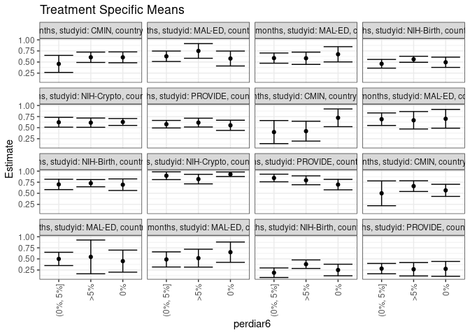

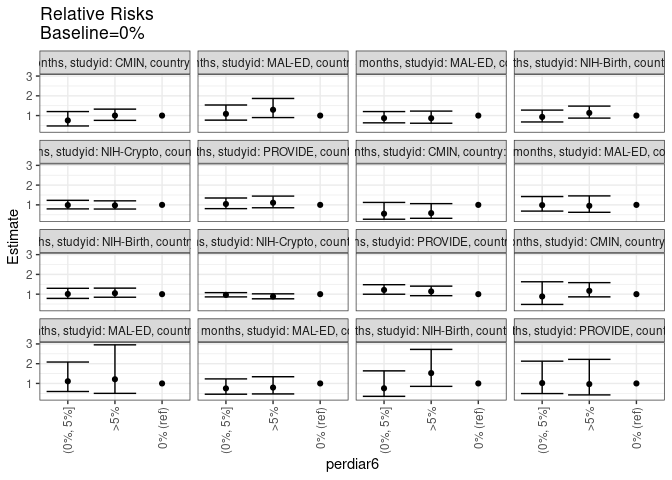

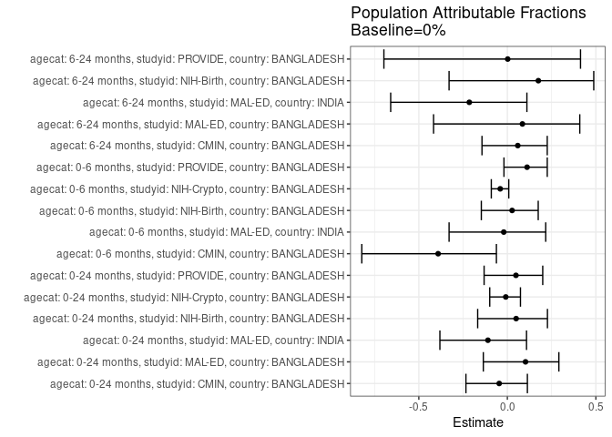

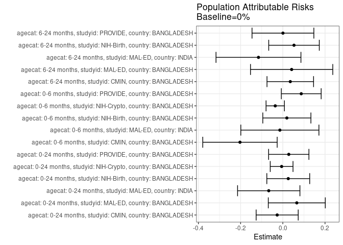

## Results Table

### Parameter: TSM

| agecat | studyid | country | intervention_level | baseline_level | estimate | ci_lower | ci_upper |
| --- | --- | --- | --- | --- | --- | --- | --- |
| 0-24 months | CMIN | BANGLADESH | 0% | NA | 0.6056338 | 0.4830890 | 0.7281786 |
| 0-24 months | CMIN | BANGLADESH | (0%, 5%] | NA | 0.4571429 | 0.2650448 | 0.6492409 |
| 0-24 months | CMIN | BANGLADESH | >5% | NA | 0.6071429 | 0.4897119 | 0.7245738 |
| 0-24 months | MAL-ED | BANGLADESH | 0% | NA | 0.5789474 | 0.4106093 | 0.7472854 |
| 0-24 months | MAL-ED | BANGLADESH | (0%, 5%] | NA | 0.6296296 | 0.5121519 | 0.7471074 |
| 0-24 months | MAL-ED | BANGLADESH | >5% | NA | 0.7500000 | 0.5844253 | 0.9155747 |
| 0-24 months | MAL-ED | INDIA | 0% | NA | 0.6744186 | 0.5029015 | 0.8459357 |
| 0-24 months | MAL-ED | INDIA | (0%, 5%] | NA | 0.5882353 | 0.4730078 | 0.7034628 |
| 0-24 months | MAL-ED | INDIA | >5% | NA | 0.5849057 | 0.4463586 | 0.7234527 |
| 0-24 months | NIH-Birth | BANGLADESH | 0% | NA | 0.4943820 | 0.3785619 | 0.6102021 |
| 0-24 months | NIH-Birth | BANGLADESH | (0%, 5%] | NA | 0.4601770 | 0.3619611 | 0.5583929 |
| 0-24 months | NIH-Birth | BANGLADESH | >5% | NA | 0.5616438 | 0.4935175 | 0.6297702 |
| 0-24 months | NIH-Crypto | BANGLADESH | 0% | NA | 0.6282051 | 0.5508013 | 0.7056090 |
| 0-24 months | NIH-Crypto | BANGLADESH | (0%, 5%] | NA | 0.6216216 | 0.5105149 | 0.7327284 |
| 0-24 months | NIH-Crypto | BANGLADESH | >5% | NA | 0.6125000 | 0.5080596 | 0.7169404 |
| 0-24 months | PROVIDE | BANGLADESH | 0% | NA | 0.5529412 | 0.4385092 | 0.6673732 |
| 0-24 months | PROVIDE | BANGLADESH | (0%, 5%] | NA | 0.5777778 | 0.4925278 | 0.6630278 |
| 0-24 months | PROVIDE | BANGLADESH | >5% | NA | 0.6136364 | 0.5141779 | 0.7130948 |
| 0-6 months | CMIN | BANGLADESH | 0% | NA | 0.7222222 | 0.5220936 | 0.9223508 |
| 0-6 months | CMIN | BANGLADESH | (0%, 5%] | NA | 0.4000000 | 0.1395476 | 0.6604524 |
| 0-6 months | CMIN | BANGLADESH | >5% | NA | 0.4210526 | 0.1965983 | 0.6455070 |
| 0-6 months | MAL-ED | INDIA | 0% | NA | 0.7000000 | 0.4880703 | 0.9119297 |
| 0-6 months | MAL-ED | INDIA | (0%, 5%] | NA | 0.6904762 | 0.5490691 | 0.8318832 |
| 0-6 months | MAL-ED | INDIA | >5% | NA | 0.6666667 | 0.4697615 | 0.8635719 |
| 0-6 months | NIH-Birth | BANGLADESH | 0% | NA | 0.6938776 | 0.5639590 | 0.8237961 |
| 0-6 months | NIH-Birth | BANGLADESH | (0%, 5%] | NA | 0.7000000 | 0.5832614 | 0.8167386 |
| 0-6 months | NIH-Birth | BANGLADESH | >5% | NA | 0.7280702 | 0.6468500 | 0.8092903 |
| 0-6 months | NIH-Crypto | BANGLADESH | 0% | NA | 0.9292929 | 0.8781896 | 0.9803962 |
| 0-6 months | NIH-Crypto | BANGLADESH | (0%, 5%] | NA | 0.8958333 | 0.8083040 | 0.9833626 |
| 0-6 months | NIH-Crypto | BANGLADESH | >5% | NA | 0.8200000 | 0.7121415 | 0.9278585 |
| 0-6 months | PROVIDE | BANGLADESH | 0% | NA | 0.6964286 | 0.5787526 | 0.8141046 |
| 0-6 months | PROVIDE | BANGLADESH | (0%, 5%] | NA | 0.8450704 | 0.7588066 | 0.9313343 |
| 0-6 months | PROVIDE | BANGLADESH | >5% | NA | 0.7931034 | 0.6930595 | 0.8931474 |
| 6-24 months | CMIN | BANGLADESH | 0% | NA | 0.5660377 | 0.4292281 | 0.7028474 |
| 6-24 months | CMIN | BANGLADESH | (0%, 5%] | NA | 0.5000000 | 0.2197112 | 0.7802888 |
| 6-24 months | CMIN | BANGLADESH | >5% | NA | 0.6615385 | 0.5406406 | 0.7824363 |
| 6-24 months | MAL-ED | BANGLADESH | 0% | NA | 0.4500000 | 0.2011920 | 0.6988080 |
| 6-24 months | MAL-ED | BANGLADESH | (0%, 5%] | NA | 0.5000000 | 0.3500866 | 0.6499134 |
| 6-24 months | MAL-ED | BANGLADESH | >5% | NA | 0.5454545 | 0.1641333 | 0.9267758 |
| 6-24 months | MAL-ED | INDIA | 0% | NA | 0.6521739 | 0.4227678 | 0.8815800 |
| 6-24 months | MAL-ED | INDIA | (0%, 5%] | NA | 0.4883721 | 0.3173946 | 0.6593495 |
| 6-24 months | MAL-ED | INDIA | >5% | NA | 0.5172414 | 0.3159219 | 0.7185608 |
| 6-24 months | NIH-Birth | BANGLADESH | 0% | NA | 0.2500000 | 0.1193951 | 0.3806049 |
| 6-24 months | NIH-Birth | BANGLADESH | (0%, 5%] | NA | 0.1886792 | 0.0809763 | 0.2963822 |
| 6-24 months | NIH-Birth | BANGLADESH | >5% | NA | 0.3809524 | 0.2849146 | 0.4769902 |
| 6-24 months | PROVIDE | BANGLADESH | 0% | NA | 0.2758621 | 0.1082883 | 0.4434359 |
| 6-24 months | PROVIDE | BANGLADESH | (0%, 5%] | NA | 0.2812500 | 0.1643962 | 0.3981038 |
| 6-24 months | PROVIDE | BANGLADESH | >5% | NA | 0.2666667 | 0.1154539 | 0.4178794 |

### Parameter: E(Y)

| agecat | studyid | country | intervention_level | baseline_level | estimate | ci_lower | ci_upper |
| --- | --- | --- | --- | --- | --- | --- | --- |
| 0-24 months | CMIN | BANGLADESH | NA | NA | 0.5789474 | 0.5004470 | 0.6574477 |
| 0-24 months | MAL-ED | BANGLADESH | NA | NA | 0.6451613 | 0.5593015 | 0.7310211 |
| 0-24 months | MAL-ED | INDIA | NA | NA | 0.6077348 | 0.5286689 | 0.6868008 |
| 0-24 months | NIH-Birth | BANGLADESH | NA | NA | 0.5201900 | 0.4695846 | 0.5707955 |
| 0-24 months | NIH-Crypto | BANGLADESH | NA | NA | 0.6225806 | 0.5684562 | 0.6767051 |
| 0-24 months | PROVIDE | BANGLADESH | NA | NA | 0.5811688 | 0.5245443 | 0.6377934 |
| 0-6 months | CMIN | BANGLADESH | NA | NA | 0.5192308 | 0.3806687 | 0.6577929 |
| 0-6 months | MAL-ED | INDIA | NA | NA | 0.6860465 | 0.5849088 | 0.7871842 |
| 0-6 months | NIH-Birth | BANGLADESH | NA | NA | 0.7130045 | 0.6535890 | 0.7724200 |
| 0-6 months | NIH-Crypto | BANGLADESH | NA | NA | 0.8934010 | 0.8497799 | 0.9370221 |
| 0-6 months | PROVIDE | BANGLADESH | NA | NA | 0.7837838 | 0.7252863 | 0.8422812 |
| 6-24 months | CMIN | BANGLADESH | NA | NA | 0.6014493 | 0.5131344 | 0.6897641 |
| 6-24 months | MAL-ED | BANGLADESH | NA | NA | 0.4918033 | 0.3610932 | 0.6225134 |
| 6-24 months | MAL-ED | INDIA | NA | NA | 0.5368421 | 0.4223932 | 0.6512910 |
| 6-24 months | NIH-Birth | BANGLADESH | NA | NA | 0.3030303 | 0.2377927 | 0.3682679 |
| 6-24 months | PROVIDE | BANGLADESH | NA | NA | 0.2764228 | 0.1950773 | 0.3577682 |

### Parameter: RR

| agecat | studyid | country | intervention_level | baseline_level | estimate | ci_lower | ci_upper |
| --- | --- | --- | --- | --- | --- | --- | --- |
| 0-24 months | CMIN | BANGLADESH | 0% | 0% | 1.0000000 | 1.0000000 | 1.000000 |
| 0-24 months | CMIN | BANGLADESH | (0%, 5%] | 0% | 0.7548173 | 0.4734735 | 1.203339 |
| 0-24 months | CMIN | BANGLADESH | >5% | 0% | 1.0024917 | 0.7577470 | 1.326286 |
| 0-24 months | MAL-ED | BANGLADESH | 0% | 0% | 1.0000000 | 1.0000000 | 1.000000 |
| 0-24 months | MAL-ED | BANGLADESH | (0%, 5%] | 0% | 1.0875421 | 0.7699799 | 1.536076 |
| 0-24 months | MAL-ED | BANGLADESH | >5% | 0% | 1.2954545 | 0.8993242 | 1.866071 |
| 0-24 months | MAL-ED | INDIA | 0% | 0% | 1.0000000 | 1.0000000 | 1.000000 |
| 0-24 months | MAL-ED | INDIA | (0%, 5%] | 0% | 0.8722110 | 0.6327342 | 1.202325 |
| 0-24 months | MAL-ED | INDIA | >5% | 0% | 0.8672739 | 0.6126221 | 1.227778 |
| 0-24 months | NIH-Birth | BANGLADESH | 0% | 0% | 1.0000000 | 1.0000000 | 1.000000 |
| 0-24 months | NIH-Birth | BANGLADESH | (0%, 5%] | 0% | 0.9308126 | 0.6779052 | 1.278073 |
| 0-24 months | NIH-Birth | BANGLADESH | >5% | 0% | 1.1360523 | 0.8725865 | 1.479068 |
| 0-24 months | NIH-Crypto | BANGLADESH | 0% | 0% | 1.0000000 | 1.0000000 | 1.000000 |
| 0-24 months | NIH-Crypto | BANGLADESH | (0%, 5%] | 0% | 0.9895201 | 0.7961004 | 1.229933 |
| 0-24 months | NIH-Crypto | BANGLADESH | >5% | 0% | 0.9750000 | 0.7898480 | 1.203554 |
| 0-24 months | PROVIDE | BANGLADESH | 0% | 0% | 1.0000000 | 1.0000000 | 1.000000 |
| 0-24 months | PROVIDE | BANGLADESH | (0%, 5%] | 0% | 1.0449173 | 0.8103156 | 1.347441 |
| 0-24 months | PROVIDE | BANGLADESH | >5% | 0% | 1.1097679 | 0.8530220 | 1.443790 |
| 0-6 months | CMIN | BANGLADESH | 0% | 0% | 1.0000000 | 1.0000000 | 1.000000 |
| 0-6 months | CMIN | BANGLADESH | (0%, 5%] | 0% | 0.5538462 | 0.2729382 | 1.123865 |
| 0-6 months | CMIN | BANGLADESH | >5% | 0% | 0.5829960 | 0.3197555 | 1.062950 |
| 0-6 months | MAL-ED | INDIA | 0% | 0% | 1.0000000 | 1.0000000 | 1.000000 |
| 0-6 months | MAL-ED | INDIA | (0%, 5%] | 0% | 0.9863946 | 0.6843974 | 1.421651 |
| 0-6 months | MAL-ED | INDIA | >5% | 0% | 0.9523810 | 0.6239074 | 1.453789 |
| 0-6 months | NIH-Birth | BANGLADESH | 0% | 0% | 1.0000000 | 1.0000000 | 1.000000 |
| 0-6 months | NIH-Birth | BANGLADESH | (0%, 5%] | 0% | 1.0088235 | 0.7850935 | 1.296310 |
| 0-6 months | NIH-Birth | BANGLADESH | >5% | 0% | 1.0492776 | 0.8437938 | 1.304801 |
| 0-6 months | NIH-Crypto | BANGLADESH | 0% | 0% | 1.0000000 | 1.0000000 | 1.000000 |
| 0-6 months | NIH-Crypto | BANGLADESH | (0%, 5%] | 0% | 0.9639946 | 0.8617509 | 1.078369 |
| 0-6 months | NIH-Crypto | BANGLADESH | >5% | 0% | 0.8823913 | 0.7651472 | 1.017601 |
| 0-6 months | PROVIDE | BANGLADESH | 0% | 0% | 1.0000000 | 1.0000000 | 1.000000 |
| 0-6 months | PROVIDE | BANGLADESH | (0%, 5%] | 0% | 1.2134345 | 0.9960513 | 1.478260 |
| 0-6 months | PROVIDE | BANGLADESH | >5% | 0% | 1.1388152 | 0.9222973 | 1.406163 |
| 6-24 months | CMIN | BANGLADESH | 0% | 0% | 1.0000000 | 1.0000000 | 1.000000 |
| 6-24 months | CMIN | BANGLADESH | (0%, 5%] | 0% | 0.8833333 | 0.4797379 | 1.626467 |
| 6-24 months | CMIN | BANGLADESH | >5% | 0% | 1.1687179 | 0.8631981 | 1.582373 |
| 6-24 months | MAL-ED | BANGLADESH | 0% | 0% | 1.0000000 | 1.0000000 | 1.000000 |
| 6-24 months | MAL-ED | BANGLADESH | (0%, 5%] | 0% | 1.1111111 | 0.5923791 | 2.084084 |
| 6-24 months | MAL-ED | BANGLADESH | >5% | 0% | 1.2121212 | 0.4972345 | 2.954819 |
| 6-24 months | MAL-ED | INDIA | 0% | 0% | 1.0000000 | 1.0000000 | 1.000000 |
| 6-24 months | MAL-ED | INDIA | (0%, 5%] | 0% | 0.7488372 | 0.4558306 | 1.230188 |
| 6-24 months | MAL-ED | INDIA | >5% | 0% | 0.7931034 | 0.4694408 | 1.339920 |
| 6-24 months | NIH-Birth | BANGLADESH | 0% | 0% | 1.0000000 | 1.0000000 | 1.000000 |
| 6-24 months | NIH-Birth | BANGLADESH | (0%, 5%] | 0% | 0.7547170 | 0.3480597 | 1.636494 |
| 6-24 months | NIH-Birth | BANGLADESH | >5% | 0% | 1.5238095 | 0.8526689 | 2.723209 |
| 6-24 months | PROVIDE | BANGLADESH | 0% | 0% | 1.0000000 | 1.0000000 | 1.000000 |
| 6-24 months | PROVIDE | BANGLADESH | (0%, 5%] | 0% | 1.0195312 | 0.4883689 | 2.128399 |
| 6-24 months | PROVIDE | BANGLADESH | >5% | 0% | 0.9666667 | 0.4210787 | 2.219168 |

### Parameter: PAR

| agecat | studyid | country | intervention_level | baseline_level | estimate | ci_lower | ci_upper |
| --- | --- | --- | --- | --- | --- | --- | --- |
| 0-24 months | CMIN | BANGLADESH | 0% | NA | -0.0266864 | -0.1263765 | 0.0730037 |
| 0-24 months | MAL-ED | BANGLADESH | 0% | NA | 0.0662139 | -0.0688583 | 0.2012861 |
| 0-24 months | MAL-ED | INDIA | 0% | NA | -0.0666838 | -0.2144212 | 0.0810536 |
| 0-24 months | NIH-Birth | BANGLADESH | 0% | NA | 0.0258080 | -0.0758003 | 0.1274163 |
| 0-24 months | NIH-Crypto | BANGLADESH | 0% | NA | -0.0056245 | -0.0595782 | 0.0483292 |
| 0-24 months | PROVIDE | BANGLADESH | 0% | NA | 0.0282277 | -0.0672734 | 0.1237287 |
| 0-6 months | CMIN | BANGLADESH | 0% | NA | -0.2029915 | -0.3793059 | -0.0266770 |
| 0-6 months | MAL-ED | INDIA | 0% | NA | -0.0139535 | -0.1990284 | 0.1711214 |
| 0-6 months | NIH-Birth | BANGLADESH | 0% | NA | 0.0191269 | -0.0948530 | 0.1331069 |
| 0-6 months | NIH-Crypto | BANGLADESH | 0% | NA | -0.0358919 | -0.0793847 | 0.0076008 |
| 0-6 months | PROVIDE | BANGLADESH | 0% | NA | 0.0873552 | -0.0070595 | 0.1817700 |
| 6-24 months | CMIN | BANGLADESH | 0% | NA | 0.0354115 | -0.0749384 | 0.1457615 |
| 6-24 months | MAL-ED | BANGLADESH | 0% | NA | 0.0418033 | -0.1531482 | 0.2367548 |
| 6-24 months | MAL-ED | INDIA | 0% | NA | -0.1153318 | -0.3165243 | 0.0858607 |
| 6-24 months | NIH-Birth | BANGLADESH | 0% | NA | 0.0530303 | -0.0667951 | 0.1728557 |
| 6-24 months | PROVIDE | BANGLADESH | 0% | NA | 0.0005607 | -0.1459375 | 0.1470589 |

### Parameter: PAF

| agecat | studyid | country | intervention_level | baseline_level | estimate | ci_lower | ci_upper |
| --- | --- | --- | --- | --- | --- | --- | --- |
| 0-24 months | CMIN | BANGLADESH | 0% | NA | -0.0460948 | -0.2339120 | 0.1131343 |
| 0-24 months | MAL-ED | BANGLADESH | 0% | NA | 0.1026316 | -0.1357451 | 0.2909764 |
| 0-24 months | MAL-ED | INDIA | 0% | NA | -0.1097252 | -0.3810039 | 0.1082647 |
| 0-24 months | NIH-Birth | BANGLADESH | 0% | NA | 0.0496126 | -0.1676160 | 0.2264271 |
| 0-24 months | NIH-Crypto | BANGLADESH | 0% | NA | -0.0090341 | -0.0995076 | 0.0739947 |
| 0-24 months | PROVIDE | BANGLADESH | 0% | NA | 0.0485705 | -0.1312794 | 0.1998280 |
| 0-6 months | CMIN | BANGLADESH | 0% | NA | -0.3909465 | -0.8220742 | -0.0618295 |
| 0-6 months | MAL-ED | INDIA | 0% | NA | -0.0203390 | -0.3291105 | 0.2167005 |
| 0-6 months | NIH-Birth | BANGLADESH | 0% | NA | 0.0268258 | -0.1469998 | 0.1743085 |
| 0-6 months | NIH-Crypto | BANGLADESH | 0% | NA | -0.0401745 | -0.0906918 | 0.0080031 |
| 0-6 months | PROVIDE | BANGLADESH | 0% | NA | 0.1114532 | -0.0191784 | 0.2253413 |
| 6-24 months | CMIN | BANGLADESH | 0% | NA | 0.0588770 | -0.1432699 | 0.2252814 |
| 6-24 months | MAL-ED | BANGLADESH | 0% | NA | 0.0850000 | -0.4167715 | 0.4090614 |
| 6-24 months | MAL-ED | INDIA | 0% | NA | -0.2148338 | -0.6589228 | 0.1103739 |
| 6-24 months | NIH-Birth | BANGLADESH | 0% | NA | 0.1750000 | -0.3291680 | 0.4879316 |
| 6-24 months | PROVIDE | BANGLADESH | 0% | NA | 0.0020284 | -0.6972781 | 0.4132091 |